```yaml
---
title: "Color-clustering con GMM en imágenes RGB — ejemplo mínimo (EM a mano)"
author: "FCFM–UNACH | Matemáticas Aplicadas"
date: "2025-08-27"
output:
  html_document:
    toc: true
    toc_float: true
    df_print: paged
  pdf_document: default
fontsize: 11pt
---
```

# Motivación breve

Al comprimir colores en una imagen o separar **regiones cromáticas** (cielo, vegetación, paredes, etc.), una estrategia simple y efectiva es modelar los **colores de píxel** $(R,G,B)$ como una **mezcla de gaussianas** (GMM). Cada **componente** (media y covarianza) describe un “color promedio + variación” (una **nube** en el cubo RGB). Con **EM** aprendemos:

- **pesos** $\pi_k$ (proporciones),
- **medias** $\mu_k\in\mathbb{R}^3$,
- **covarianzas** $\Sigma_k\in\mathbb{R}^{3\times 3}$.

Luego podemos:

- **Cuantizar** la imagen: reemplazar cada píxel por la **media** de su componente más probable (MAP).
- Construir la **posterior mean image**: color = $\sum_k \gamma_{ik}\mu_k$, que usa **responsabilidades blandas** $\gamma_{ik}$.

# Formulación (3D, RGB) y EM

Sea $X\in\mathbb{R}^3$ el vector normalizado $(R,G,B)\in[0,1]^3$. Modelo:

$$p(x\mid\Theta)=\sum_{k=1}^{K}\pi_k\,\mathcal N\!\big(x\mid
\mu_k,\Sigma_k\big),\quad
\pi_k>0,\ \sum_k \pi_k = 1.$$

Variables latentes $Z_i\in\{1,\dots,K\}$. **E-step**:

$$\gamma_{ik}=\frac{\pi_k\,\phi_3(x_i;\mu_k,\Sigma_k)}
{\sum_{j=1}^K \pi_j\,\phi_3(x_i;\mu_j,\Sigma_j)}.$$

**M-step**:

$$N_k=\sum_i \gamma_{ik},\quad
\pi_k^{new}=\frac{N_k}{N},\quad
\mu_k^{new}=\frac{1}{N_k}\sum_i \gamma_{ik}x_i,\quad
\Sigma_k^{new}=\frac{1}{N_k}\sum_i \gamma_{ik}
(x_i-\mu_k^{new})(x_i-\mu_k^{new})^\top.$$

> Para el **cálculo manual** usaremos $\Sigma_k$ **diagonal** (independencia entre canales dentro del componente), lo que simplifica $\phi_3$ a producto de normales 1D.

# Tabla mínima (6 píxeles) para una vuelta de EM **a mano**

Elegimos 6 “píxeles” (RGB en [0,255]) representativos de **tres colores** (rojo, verde, azul) con pequeñas variaciones. Convertimos a $[0,1]$.

```r
RGB_255 <- matrix(c(
  230,  30,  35,   # rojo 1
  240,  35,  40,   # rojo 2
   20, 220,  25,   # verde 1 (frontera)
   25, 210,  35,   # verde 2
   30,  35, 230,   # azul 1 (frontera)
   28,  40, 240    # azul 2
), ncol = 3, byrow = TRUE)
colnames(RGB_255) <- c("R","G","B")

X <- RGB_255/255  # normalizado [0,1]
DF <- data.frame(i = 1:nrow(X), round(X, 4))
DF
```

```
##   i      R      G      B
## 1 1 0.9020 0.1176 0.1373
## 2 2 0.9412 0.1373 0.1569
## 3 3 0.0784 0.8627 0.0980
## 4 4 0.0980 0.8235 0.1373
## 5 5 0.1176 0.1373 0.9020
## 6 6 0.1098 0.1569 0.9412
```

**Inicialización (intuitiva, K=3, diagonal):**

- Pesos: $\pi_k=1/3$.
- Medias (en [0,1]): $\mu_1=(0.9,0.1,0.1)$ rojo, $\mu_2=(0.1,0.9,0.1)$ verde, $\mu_3=(0.1,0.1,0.9)$ azul.
- Desv. estándar por canal (suave): $\sigma_k=(0.08,0.08,0.08)$ para todos.

```r
K  <- 3
pi  <- rep(1/K, K)
mu  <- rbind(c(0.9, 0.1, 0.1),
             c(0.1, 0.9, 0.1),
             c(0.1, 0.1, 0.9))
sd  <- rbind(c(0.08, 0.08, 0.08),
             c(0.08, 0.08, 0.08),
             c(0.08, 0.08, 0.08))
```

## E-step (una vuelta)

Densidad 3D diagonal: $\phi_3(x;\mu,\Sigma)=\prod_{c\in\{R,G,B\}}\phi\big(x^{(c)};\mu^{(c)},\sigma^{(c)}\big)$.

```r
d3_diag <- function(x, mu, sd){
  dnorm(x[1], mu[1], sd[1]) *
  dnorm(x[2], mu[2], sd[2]) *
  dnorm(x[3], mu[3], sd[3])
}

dens <- sapply(1:K, function(k) apply(X, 1, function(x) d3_diag(x, mu[k,], sd[k,])))
num  <- sweep(dens, 2, pi, `*`)  # multiplicar columnas por pesos
den  <- rowSums(num)
Gamma <- num / den               # responsabilidades (N x K)
Gamma_round <- round(Gamma, 4)
cbind(DF, Gamma_round)
```

```
##   i      R      G      B 1 2 3
## 1 1 0.9020 0.1176 0.1373 1 0 0
## 2 2 0.9412 0.1373 0.1569 1 0 0
## 3 3 0.0784 0.8627 0.0980 0 1 0
## 4 4 0.0980 0.8235 0.1373 0 1 0
## 5 5 0.1176 0.1373 0.9020 0 0 1
## 6 6 0.1098 0.1569 0.9412 0 0 1
```

## M-step (actualización)

```r
Nk   <- colSums(Gamma)
pi_n <- Nk / nrow(X)
mu_n <- t(Gamma) %*% X / Nk            # (K x 3)
# varianzas diagonales por canal
var_n <- matrix(0, nrow=K, ncol=3)
for(k in 1:K){
  Xc <- sweep(X, 2, mu_n[k,], `-`)
  var_n[k,] <- colSums(Gamma[,k] * Xc^2)/Nk[k]
}
sd_n <- sqrt(var_n)

Ms <- data.frame(
  componente = paste0(1:K),
  pi_k = pi_n,
  mu_R = mu_n[,1], mu_G = mu_n[,2], mu_B = mu_n[,3],
  sd_R = sd_n[,1], sd_G = sd_n[,2], sd_B = sd_n[,3],
  stringsAsFactors = FALSE
)
nums <- sapply(Ms, is.numeric); Ms_round <- Ms
Ms_round[,nums] <- lapply(Ms_round[,nums], function(z) round(z, 4))
Ms_round
```

```
##   componente   pi_k   mu_R   mu_G   mu_B   sd_R   sd_G   sd_B
## 1          1 0.3333 0.9216 0.1275 0.1471 0.0196 0.0098 0.0098
## 2          2 0.3333 0.0882 0.8431 0.1176 0.0098 0.0196 0.0196
## 3          3 0.3333 0.1137 0.1471 0.9216 0.0039 0.0098 0.0196
```

### Log-verosimilitud (sube tras EM)

```r
loglik <- function(X, pi, mu, sd){
  dens <- sapply(1:length(pi), function(k) apply(X, 1, function(x) d3_diag(x, mu[k,], sd[k,])))
  sum(log(rowSums(sweep(dens, 2, pi, `*`))))
}
ll0 <- loglik(X, pi, mu, sd)
ll1 <- loglik(X, pi_n, mu_n, sd_n)
c(ll_inicial = round(ll0, 4), ll_despues_EM = round(ll1, 4))
```

```
##    ll_inicial ll_despues_EM
##       20.4677       47.4043
```

# De la tabla mínima a una imagen sintética

Generamos una **imagen sintética** (alto × ancho × 3) con 3 regiones cromáticas + ruido suave, para visualizar cuantización.

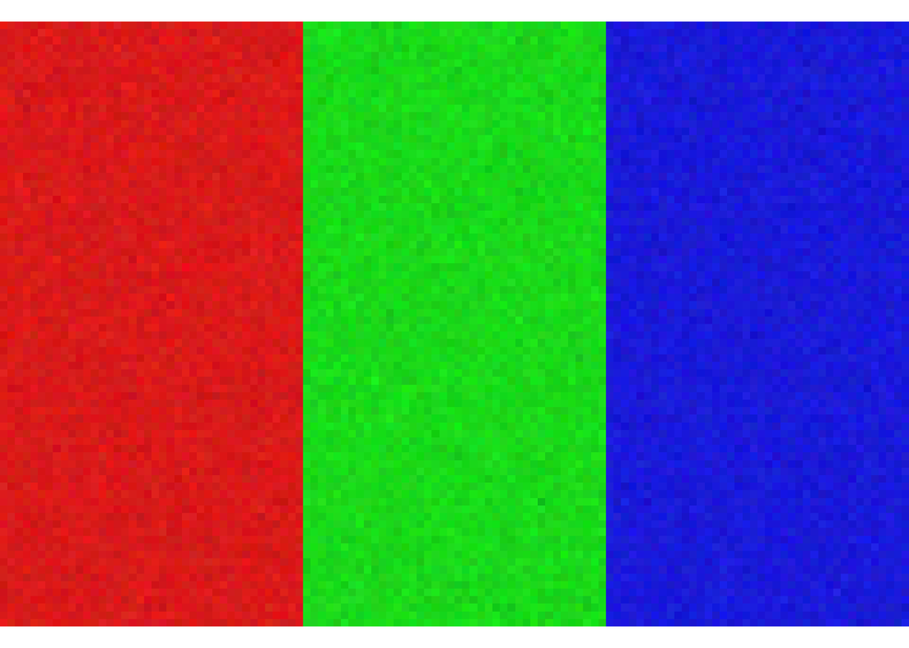

```r
set.seed(7)
H <- 80; W <- 120
img <- array(0, dim = c(H, W, 3))

# tres bloques de color (R, G, B) con leve ruido
img[, 1:(W/3),   1] <- 0.85 + rnorm(H*W/3, 0, 0.03)
img[, 1:(W/3),   2] <- 0.10 + rnorm(H*W/3, 0, 0.02)
img[, 1:(W/3),   3] <- 0.10 + rnorm(H*W/3, 0, 0.02)

img[, (W/3+1):(2*W/3), 1] <- 0.10 + rnorm(H*W/3, 0, 0.02)
img[, (W/3+1):(2*W/3), 2] <- 0.85 + rnorm(H*W/3, 0, 0.03)
img[, (W/3+1):(2*W/3), 3] <- 0.10 + rnorm(H*W/3, 0, 0.02)

img[, (2*W/3+1):W, 1] <- 0.10 + rnorm(H*W/3, 0, 0.02)
img[, (2*W/3+1):W, 2] <- 0.10 + rnorm(H*W/3, 0, 0.02)
img[, (2*W/3+1):W, 3] <- 0.85 + rnorm(H*W/3, 0, 0.03)

# recorte a [0,1]
img[img<0] <- 0; img[img>1] <- 1

# muestra
grid::grid.raster(img, interpolate = FALSE)
```

Convertimos la imagen a una matriz $N\times 3$ (píxeles por filas, RGB por columnas).

```r
Ximg <- matrix(img, ncol = 3)  # (H*W) x 3
dim(Ximg)
```

```
## [1] 9600    3
```

# Ajuste con `mclust` (G=3..6) y posterior mean image

Ajustamos un GMM y generamos dos versiones de la imagen:

- **MAP image**: mu_k del componente con mayor $\gamma_{ik}$.
- **Posterior mean image**: $\sum_k \gamma_{ik}\,\mu_k$.

```r
# install.packages("mclust")  # si hace falta
library(mclust)
fit <- Mclust(Ximg, G = 3:6)   # selección automática de K por BIC
summary(fit)
```

```
## ----------------------------------------------------
## Gaussian finite mixture model fitted by EM algorithm
## ----------------------------------------------------
##
## Mclust EVI (diagonal, equal volume, varying shape) model with 3 components:
##
##  log-likelihood    n df      BIC      ICL
##        57193.88 9600 18 114222.7 114222.7
##
## Clustering table:
##    1    2    3
## 3200 3200 3200
```

```r
K_hat <- fit$G
cat("Número de componentes elegido (BIC):", K_hat, "\n")
```

```
## Número de componentes elegido (BIC): 3
```

```r
# responsabilidades (N x K) y medias (3 x K)
Z   <- fit$z
MU  <- t(fit$parameters$mean)  # K x 3

# (1) MAP (asignación dura)
k_map <- max.col(Z)                 # argmax por fila
X_map <- MU[k_map, ]                # N x 3
img_map <- array(X_map, dim = c(H, W, 3))

# (2) Posterior mean (asignación blanda)
X_soft <- Z %*% MU                  # N x 3
img_soft <- array(X_soft, dim = c(H, W, 3))
```

## Visualización

[figure not shown]

```r
par(mfrow = c(1,3), mar = c(1,1,2,1))
plot.new(); grid::grid.raster(img, interpolate = FALSE);    title("Original")
plot.new(); grid::grid.raster(img_map, interpolate = FALSE); title("MAP (cuantización dura)")
plot.new(); grid::grid.raster(img_soft, interpolate = FALSE);title("Posterior mean (blanda)")
```

```r
par(mfrow = c(1,1))
```